# Netflix Content Analysis

# Introduction

This report draws on IMDb and TMDb data for Netflix movies up to 2023 to identify what works in streaming content. Three questions are addressed: what types of movies different countries produce, how audience engagement varies across countries, and how movie length differs by market. These findings are intended to inform content strategy for a new streaming platform.

## Genre Preferences by Country

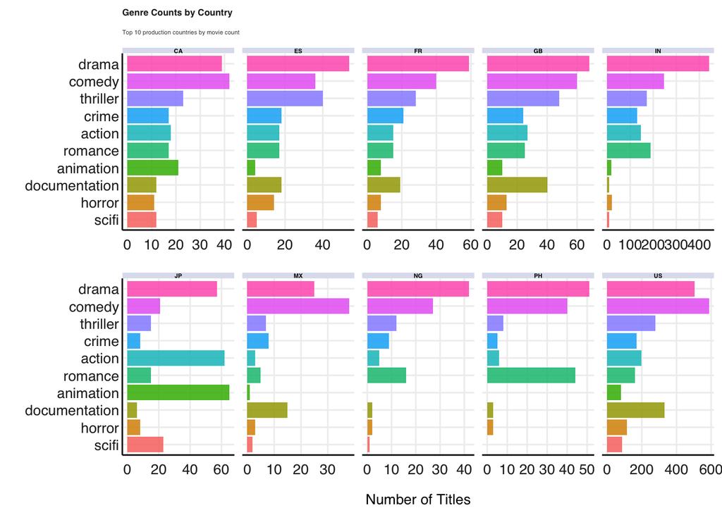

## What Audiences Rate Highest

To understand what content audiences value most, median IMDb scores were computed per genre. Titles can belong to multiple genres, so each title was counted once per genre using `grepl()`. History and documentary content score highest — niche but high-satisfaction genres worth considering for a differentiated content slate.

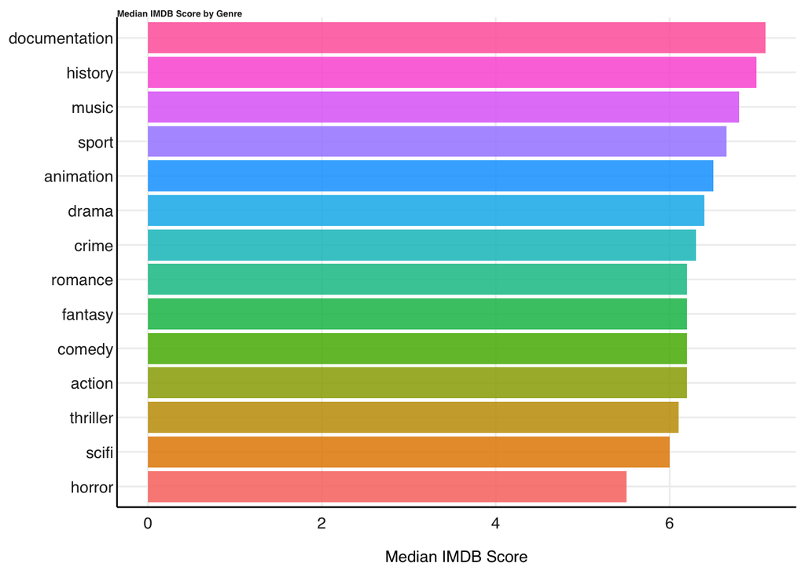

## Audience Engagement by Country

TMDb popularity scores reflect active audience engagement (searches, watchlists, and ratings activity) making them a better proxy for streaming performance than critic scores alone. Japanese and English-language content (GB, US) drives the highest median engagement globally, while Nigerian and Filipino content remains more locally concentrated.

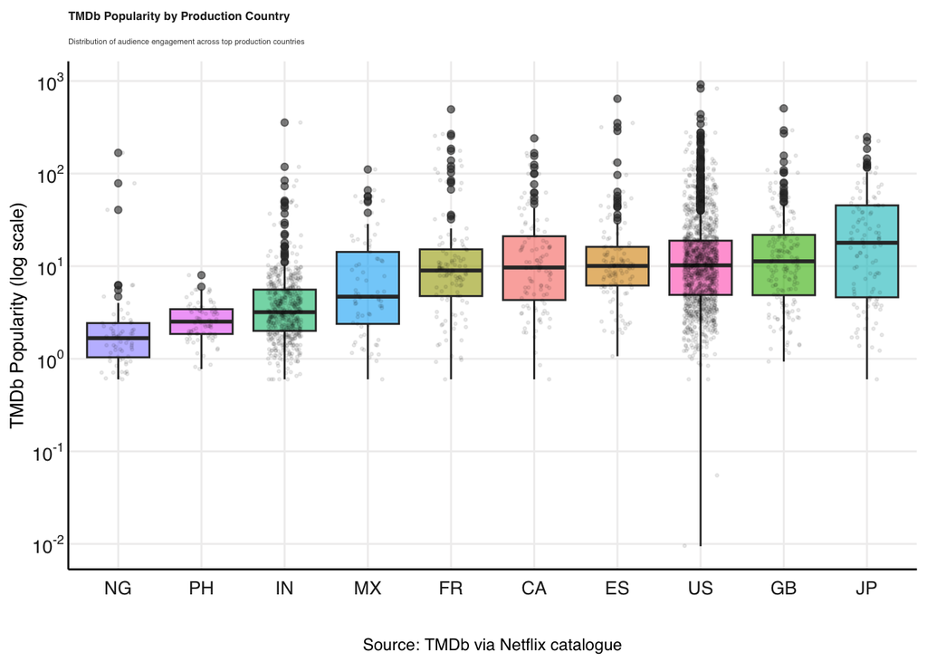

## Movie Runtime by Country

Runtime distributions were compared across the top 10 production countries to understand whether movie length preferences vary by market. Each movie is assigned to its primary production country for grouping purposes.

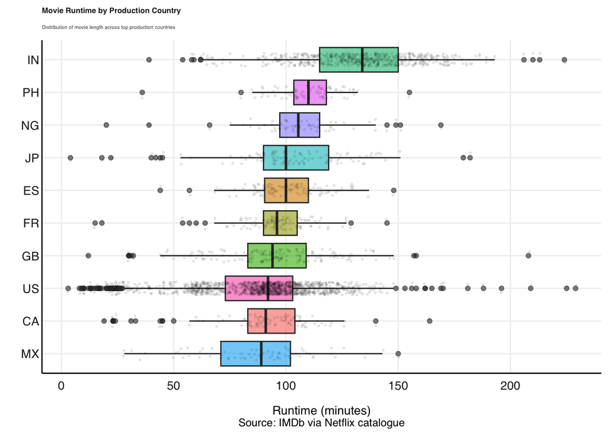

Indian cinema stands out with the longest median runtime by a clear margin, consistent with the famously long format of Bollywood productions. Most other countries cluster tightly around 90–110 minutes — the global streaming sweet spot. The US shows the widest spread, reflecting the sheer variety of its production output.